# L19-L21-catcher-framing

```r
library(tidyverse)
# Anchor here() to the course folder, regardless of where the R session started
here::i_am("chapters/ch07-catcher-framing/lecture/L19-21-catcher-framing.qmd")
```

```
here() starts at /Users/philip/Library/CloudStorage/OneDrive-USAFA(AFAcademy.AF.edu)/usafa-or476-fall26
```

```r
data_dir <- here::here("data")
taken_path <- file.path(data_dir, "sc_taken_2022.rds")

# Download and build the season only if the taken-pitch file does not exist yet
if (!file.exists(taken_path)) {
  day_dir <- file.path(data_dir, "savant_2022")
  dir.create(day_dir, recursive = TRUE, showWarnings = FALSE)

  # One request per day; each day is cached so an interrupted run resumes
  savant_day <- function(date) {
    path <- file.path(day_dir, paste0(date, ".rds"))
    if (!file.exists(path)) {
      url <- paste0(
        "https://baseballsavant.mlb.com/statcast_search/csv?all=true&hfGT=R%7C",
        "&game_date_gt=", date, "&game_date_lt=", date, "&type=details"
      )
      write_rds(read_csv(url, col_types = cols(.default = col_character())), path)
    }
    read_rds(path)
  }

  sc2022 <- seq(as.Date("2022-04-07"), as.Date("2022-10-05"), by = "day") |>
    as.character() |>
    map(savant_day, .progress = TRUE) |>
    list_rbind() |>
    type_convert()
  write_rds(sc2022, file.path(data_dir, "statcast_2022.rds"))

  sc_taken <- sc2022 |>
    mutate(
      Outcome = case_when(
        description %in% c("ball", "blocked_ball", "pitchout",
                           "hit_by_pitch") ~ "ball",
        description == "called_strike" ~ "called_strike",
        .default = "swing"
      ),
      Home = ifelse(inning_topbot == "Bot", 1, 0),
      Count = paste(balls, strikes, sep = "-")
    ) |>
    filter(Outcome != "swing") |>
    select(pitch_type, release_speed, description, stand, p_throws, Outcome,
           plate_x, plate_z, fielder_2_1 = fielder_2, pitcher, batter,
           Count, Home, zone)
  write_rds(sc_taken, taken_path, compress = "xz")
}

sc_taken <- read_rds(taken_path)
```

```r
crcblue <- "#2905a1"
crc_fc  <- c("#2905a1", "#e41a1c", "#4daf4a", "#984ea3")

plate_width <- 17 + 2 * (9/pi)
k_zone_plot <- ggplot(
  NULL, aes(x = plate_x, y = plate_z)
) +
  geom_rect(
    xmin = -(plate_width/2)/12,
    xmax = (plate_width/2)/12,
    ymin = 1.5,
    ymax = 3.6, color = crcblue, alpha = 0
  ) +
  coord_equal() +
  scale_x_continuous(
    "Horizontal location (ft.)",
    limits = c(-2, 2)
  ) +
  scale_y_continuous(
    "Vertical location (ft.)",
    limits = c(0, 5)
  )
```

Plot a random sample of 2000 pitches on top of the strike zone.

```r
taken <- sc_taken |>
  filter(!is.na(plate_x), !is.na(plate_z))
tibble(taken)
```

```
# A tibble: 369,025 × 14
   pitch_type release_speed description stand p_throws Outcome plate_x plate_z
   <chr>              <dbl> <chr>       <chr> <chr>    <chr>     <dbl>   <dbl>
 1 FF                  95.4 ball        R     R        ball     -0.125  0.747
 2 FF                  95.5 ball        R     R        ball      0.256  1.29
 3 FF                  95.1 ball        R     R        ball      0.737  0.764
 4 FF                  94   ball        L     R        ball     -1.29   2.12
 5 SL                  85   ball        L     R        ball      0.120  0.540
 6 ST                  81   ball        L     R        ball     -0.943 -0.0503
 7 FF                  95.6 ball        L     R        ball     -0.762  1.34
 8 FF                  93.4 ball        R     L        ball     -0.645  3.59
 9 FS                  85.8 ball        L     R        ball     -1.55   1.83
10 FC                  83.4 ball        R     R        ball      0.423  1.41
# ℹ 369,015 more rows
# ℹ 6 more variables: fielder_2_1 <dbl>, pitcher <dbl>, batter <dbl>,
#   Count <chr>, Home <dbl>, zone <dbl>
```

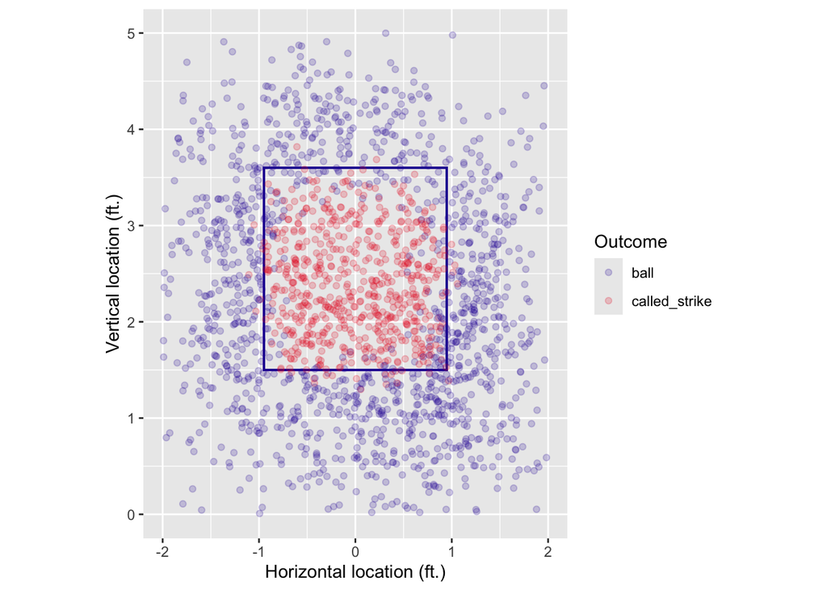

```r
k_zone_plot %+%
  sample_n(taken, size = 2000) +
  aes(color = Outcome) +
  geom_point(alpha = 0.2) +
  scale_color_manual(values = crc_fc)
```

Fit a predicted called strike model based on pitch location

```r
library(mgcv)
strike_mod <- gam(
  Outcome == "called_strike" ~ s(plate_x, plate_z),
  family = binomial,
  data = taken
)
```

How does the GAM compare to other models? Each model below was trained on 10,000, 50,000, and 300,000 pitches from 2022 and evaluated on the same 50,000 held-out pitches.

| Model | Log loss (10k) | Log loss (50k) | Log loss (300k) | Brier (300k) | Accuracy (300k) | Fit time (300k) |
| --- | --- | --- | --- | --- | --- | --- |
| GAM (textbook) | **0.157** | **0.156** | **0.156** | 0.048 | 93.1% | 44.5 s |
| Gradient boosting | 0.162 | 0.158 | 0.157 | 0.048 | 93.2% | 0.6 s |
| Random forest | 0.167 | 0.167 | 0.167 | 0.050 | 93.0% | 29.4 s |
| Polynomial logistic | 0.169 | 0.169 | 0.169 | 0.053 | 92.6% | 0.4 s |
| k-NN (k = 50) | 0.166 | 0.167 | 0.171 | 0.049 | 93.1% | 20.0 s |
| Distance to edge | 0.171 | 0.171 | 0.171 | 0.053 | 92.5% | 0.2 s |
| Classification tree | 0.252 | 0.255 | 0.252 | 0.068 | 92.3% | 0.7 s |
| Rulebook zone | 0.263 | 0.263 | 0.263 | 0.069 | 92.5% | 0.1 s |

Use the fitted model to generate predicted prob strike for all taken pitches

```r
library(broom)
hats <- strike_mod |>
  augment(type.predict = "response")
hats
```

```
# A tibble: 369,025 × 9
   Outcome == "called_stri…¹ plate_x plate_z  .fitted  .se.fit   .resid     .hat
   <lgl>                       <dbl>   <dbl>    <dbl>    <dbl>    <dbl>    <dbl>
 1 FALSE                      -0.125  0.747  9.19e- 6 5.67e- 6 -4.29e-3 3.50e- 6
 2 FALSE                       0.256  1.29   6.50e- 2 2.71e- 3 -3.67e-1 1.21e- 4
 3 FALSE                       0.737  0.764  3.04e- 7 3.49e- 7 -7.79e-4 4.00e- 7
 4 FALSE                      -1.29   2.12   4.46e- 3 5.10e- 4 -9.45e-2 5.85e- 5
 5 FALSE                       0.120  0.540  4.38e- 8 6.20e- 8 -2.96e-4 8.77e- 8
 6 FALSE                      -0.943 -0.0503 2.22e-16 1.25e-15 -2.11e-8 7.05e-15
 7 FALSE                      -0.762  1.34   6.51e- 2 3.80e- 3 -3.67e-1 2.37e- 4
 8 FALSE                      -0.645  3.59   1.29e- 1 4.97e- 3 -5.25e-1 2.20e- 4
 9 FALSE                      -1.55   1.83   1.13e- 5 5.07e- 6 -4.76e-3 2.27e- 6
10 FALSE                       0.423  1.41   2.41e- 1 5.55e- 3 -7.43e-1 1.68e- 4
# ℹ 369,015 more rows
# ℹ abbreviated name: ¹`Outcome == "called_strike"`
# ℹ 2 more variables: .sigma <lgl>, .cooksd <dbl>
```

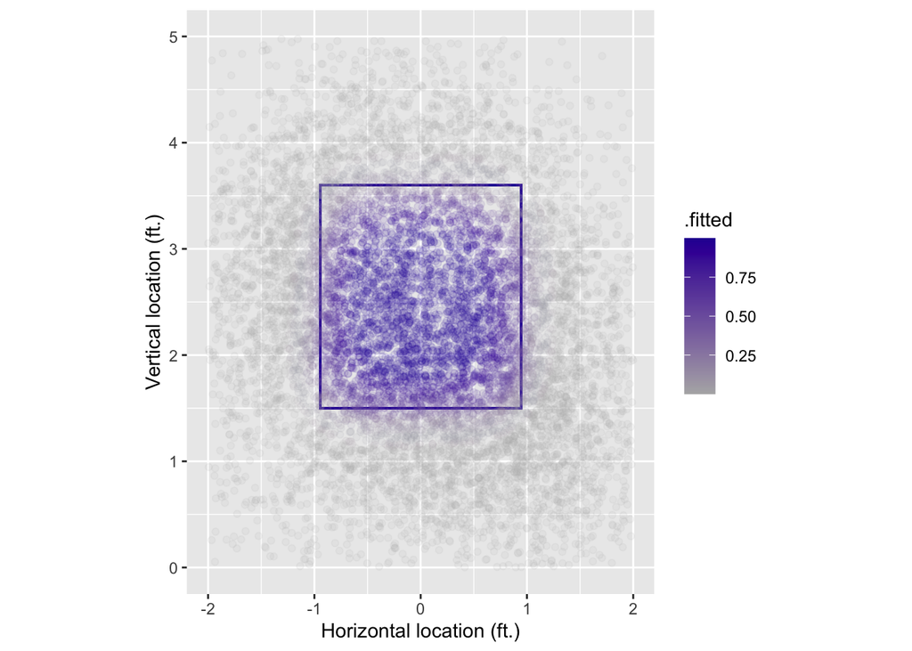

```r
k_zone_plot %+% sample_n(hats, 10000) +
  geom_point(aes(color = .fitted), alpha = 0.1) +
  scale_color_gradient(low = "gray70", high = crcblue)
```

Add the predicted probability of a strike to each taken pitch. The rows of `hats` are in the same order as `taken`.

```r
taken <- taken |>
  mutate(prob_strike = hats$.fitted)
```

How would we use these data to measure the framing ability of each catcher?

Look up player names from MLBAM IDs. The Chadwick register is downloaded once and saved to `data/`.

```r
id_path <- file.path(data_dir, "player_ids.rds")
if (!file.exists(id_path)) {
  baseballr::chadwick_player_lu() |>
    filter(!is.na(key_mlbam)) |>
    transmute(mlb_id = key_mlbam, name = paste(name_first, name_last)) |>
    write_rds(id_path)
}
player_names <- read_rds(id_path)
```

Compare each catcher’s called strikes to the strikes the GAM expected. A positive `strikes_added` means the catcher received more strikes than the pitch locations predict.

```r
framing_table <- function(pitches) {
  pitches |>
    group_by(fielder_2_1) |>
    summarize(
      pitches = n(),
      called_strikes = sum(Outcome == "called_strike"),
      expected_strikes = sum(prob_strike),
      strikes_added = called_strikes - expected_strikes
    ) |>
    left_join(player_names, by = c("fielder_2_1" = "mlb_id")) |>
    relocate(catcher = name) |>
    slice_max(strikes_added, n = 20)
}

framing_table(taken)
```

```
# A tibble: 20 × 6
   catcher     fielder_2_1 pitches called_strikes expected_strikes strikes_added
   <chr>             <dbl>   <int>          <int>            <dbl>         <dbl>
 1 Jose Trevi…      624431    6893           2284            2107.         177.
 2 Jonah Heim       641680    7795           2415            2302.         113.
 3 Adley Ruts…      668939    6251           2027            1941.          85.6
 4 Cal Raleigh      663728    7187           2236            2163.          72.6
 5 Sean Murphy      669221    8639           2668            2598.          70.3
 6 Omar Narvá…      553882    6294           2079            2010.          69.1
 7 Alejandro …      672386    5205           1777            1713.          63.8
 8 Tomás Nido       621512    6310           2063            2003.          59.6
 9 Kyle Higas…      543309    5124           1631            1573.          58.1
10 Travis d'A…      518595    7410           2384            2333.          51.5
11 Brian Serv…      661531    4170           1286            1237.          48.5
12 Yadier Mol…      425877    5420           1796            1748.          48.1
13 Seby Zavala      664874    3979           1247            1199.          47.7
14 Austin Hed…      595978    6446           2071            2023.          47.5
15 Víctor Car…      605170    6357           2064            2022.          42.4
16 Tyler Hein…      623168    3913           1208            1167.          41.4
17 Ryan Jeffe…      680777    4096           1301            1264.          36.7
18 Yasmani Gr…      518735    4687           1389            1353.          35.8
19 Christian …      543877    7484           2402            2370.          32.5
20 Austin Bar…      605131    3708           1256            1225.          30.6
```

Should every taken pitch count toward a catcher’s framing?

Keep only borderline pitches, those within `buffer` feet of the edge of the rulebook zone.

```r
x_edge <- (plate_width/2)/12
z_bot <- 1.5
z_top <- 3.6
buffer <- 0.25  # feet, about 3 inches

borderline <- taken |>
  filter(
    abs(plate_x) <= x_edge + buffer,
    between(plate_z, z_bot - buffer, z_top + buffer),
    !(abs(plate_x) <= x_edge - buffer &
        between(plate_z, z_bot + buffer, z_top - buffer))
  )
nrow(borderline)
```

```
[1] 122858
```

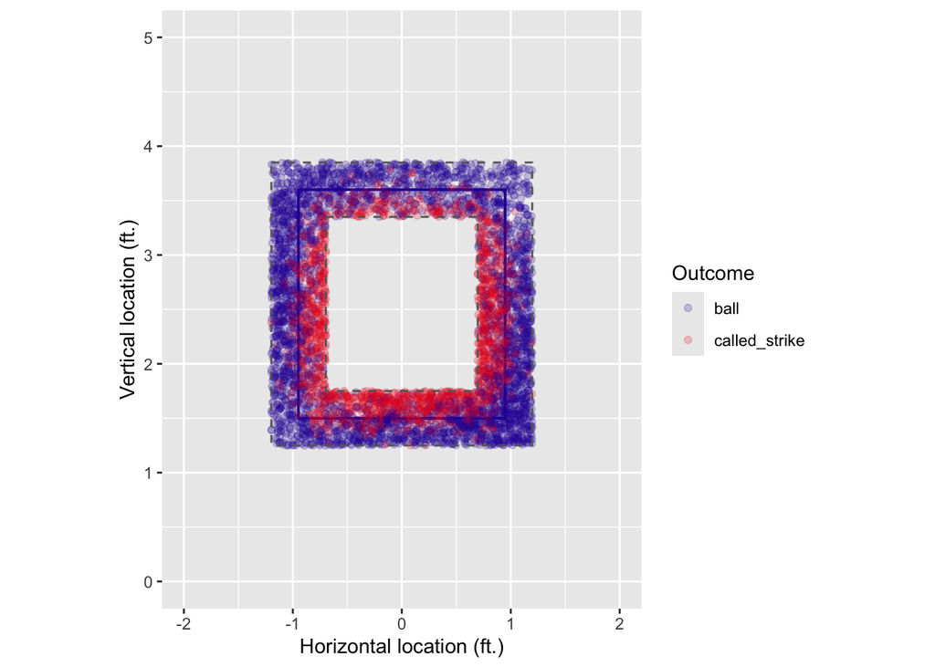

```r
k_zone_plot %+%
  sample_n(borderline, 5000) +
  aes(color = Outcome) +
  geom_point(alpha = 0.2) +
  annotate("rect", xmin = -x_edge - buffer, xmax = x_edge + buffer,
           ymin = z_bot - buffer, ymax = z_top + buffer,
           fill = NA, color = "gray40", linetype = "dashed") +
  annotate("rect", xmin = -x_edge + buffer, xmax = x_edge - buffer,
           ymin = z_bot + buffer, ymax = z_top - buffer,
           fill = NA, color = "gray40", linetype = "dashed") +
  scale_color_manual(values = crc_fc)
```

Top 20 catchers in strikes added on borderline pitches.

```r
framing_table(borderline)
```

```
# A tibble: 20 × 6
   catcher     fielder_2_1 pitches called_strikes expected_strikes strikes_added
   <chr>             <dbl>   <int>          <int>            <dbl>         <dbl>
 1 Jose Trevi…      624431    2259            979             812.         167.
 2 Jonah Heim       641680    2621           1056             950.         106.
 3 Omar Narvá…      553882    2095            824             749.          74.9
 4 Sean Murphy      669221    2911           1105            1031.          74.4
 5 Cal Raleigh      663728    2347            859             795.          63.9
 6 Adley Ruts…      668939    2019            767             707.          60.0
 7 Tomás Nido       621512    1980            764             708.          55.8
 8 Alejandro …      672386    1680            676             621.          54.8
 9 Kyle Higas…      543309    1691            642             588.          54.4
10 Travis d'A…      518595    2428            884             831.          52.8
11 Yadier Mol…      425877    1912            705             665.          40.4
12 Víctor Car…      605170    2138            817             778.          39.0
13 Seby Zavala      664874    1197            467             430.          36.6
14 Brian Serv…      661531    1400            529             493.          36.5
15 Tyler Hein…      623168    1288            463             428.          35.3
16 Austin Hed…      595978    2093            767             735.          32.1
17 Yasmani Gr…      518735    1490            534             504.          29.9
18 Austin Bar…      605131    1297            503             474.          28.8
19 Ryan Jeffe…      680777    1360            485             461.          24.3
20 Christian …      543877    2465            859             835.          24.0
```

How many runs is one extra strike worth? Turning a ball into a strike changes run expectancy, and the size of that change depends on the count. We use Statcast’s `delta_run_exp`, the change in run expectancy on each pitch.

```r
sc2022 <- read_rds(file.path(data_dir, "statcast_2022.rds"))

count_values <- sc2022 |>
  filter(description %in% c("ball", "called_strike")) |>
  group_by(balls, strikes, description) |>
  summarize(run_value = mean(delta_run_exp, na.rm = TRUE), .groups = "drop") |>
  pivot_wider(names_from = description, values_from = run_value) |>
  mutate(
    Count = paste(balls, strikes, sep = "-"),
    strike_value = ball - called_strike
  )
count_values
```

```
# A tibble: 12 × 6
   balls strikes   ball called_strike Count strike_value
   <dbl>   <dbl>  <dbl>         <dbl> <chr>        <dbl>
 1     0       0 0.0359       -0.0401 0-0         0.0760
 2     0       1 0.0271       -0.0545 0-1         0.0816
 3     0       2 0.0211       -0.162  0-2         0.183
 4     1       0 0.0596       -0.0492 1-0         0.109
 5     1       1 0.0496       -0.0608 1-1         0.110
 6     1       2 0.0378       -0.184  1-2         0.222
 7     2       0 0.111        -0.0595 2-0         0.170
 8     2       1 0.102        -0.0726 2-1         0.174
 9     2       2 0.0959       -0.222  2-2         0.317
10     3       0 0.132        -0.0702 3-0         0.202
11     3       1 0.200        -0.0796 3-1         0.280
12     3       2 0.284        -0.318  3-2         0.602
```

Average the value of a strike over the counts of the borderline pitches, then convert strikes added to runs added.

```r
strike_value <- borderline |>
  left_join(count_values, by = "Count") |>
  summarize(strike_value = mean(strike_value)) |>
  pull(strike_value)
strike_value
```

```
[1] 0.1371654
```

```r
catcher_runs <- framing_table(borderline) |>
  mutate(runs_added = strikes_added * strike_value)
catcher_runs
```

```
# A tibble: 20 × 7
   catcher     fielder_2_1 pitches called_strikes expected_strikes strikes_added
   <chr>             <dbl>   <int>          <int>            <dbl>         <dbl>
 1 Jose Trevi…      624431    2259            979             812.         167.
 2 Jonah Heim       641680    2621           1056             950.         106.
 3 Omar Narvá…      553882    2095            824             749.          74.9
 4 Sean Murphy      669221    2911           1105            1031.          74.4
 5 Cal Raleigh      663728    2347            859             795.          63.9
 6 Adley Ruts…      668939    2019            767             707.          60.0
 7 Tomás Nido       621512    1980            764             708.          55.8
 8 Alejandro …      672386    1680            676             621.          54.8
 9 Kyle Higas…      543309    1691            642             588.          54.4
10 Travis d'A…      518595    2428            884             831.          52.8
11 Yadier Mol…      425877    1912            705             665.          40.4
12 Víctor Car…      605170    2138            817             778.          39.0
13 Seby Zavala      664874    1197            467             430.          36.6
14 Brian Serv…      661531    1400            529             493.          36.5
15 Tyler Hein…      623168    1288            463             428.          35.3
16 Austin Hed…      595978    2093            767             735.          32.1
17 Yasmani Gr…      518735    1490            534             504.          29.9
18 Austin Bar…      605131    1297            503             474.          28.8
19 Ryan Jeffe…      680777    1360            485             461.          24.3
20 Christian …      543877    2465            859             835.          24.0
# ℹ 1 more variable: runs_added <dbl>
```

For scale, compare to the top hitters. Recall from Chapter 5 that the linear weight of an event is the average change in run expectancy over the plate appearances that end in that event.

```r
pa <- sc2022 |>
  group_by(game_pk, at_bat_number) |>
  summarize(
    batter = first(batter),
    event = events[which.max(pitch_number)],
    run_value = sum(delta_run_exp, na.rm = TRUE),
    .groups = "drop"
  ) |>
  filter(!is.na(event), event != "truncated_pa")

linear_weights <- pa |>
  group_by(event) |>
  summarize(PA = n(), weight = mean(run_value)) |>
  arrange(desc(weight))
linear_weights
```

```
# A tibble: 21 × 3
   event              PA weight
   <chr>           <int>  <dbl>
 1 home_run         5215 1.55
 2 triple            643 1.02
 3 double           7940 0.722
 4 field_error      1138 0.444
 5 fielders_choice   383 0.428
 6 single          25876 0.428
 7 hit_by_pitch     2045 0.343
 8 walk            14378 0.337
 9 catcher_interf     74 0.282
10 intent_walk       475 0.0150
# ℹ 11 more rows
```

Top 20 batters in runs above average.

```r
batter_runs <- pa |>
  left_join(select(linear_weights, event, weight), by = "event") |>
  group_by(batter) |>
  summarize(PA = n(), batting_runs = sum(weight - mean(pa$run_value))) |>
  left_join(player_names, by = c("batter" = "mlb_id")) |>
  relocate(batter_name = name) |>
  slice_max(batting_runs, n = 20)
batter_runs
```

```
# A tibble: 20 × 4
   batter_name      batter    PA batting_runs
   <chr>             <dbl> <int>        <dbl>
 1 Aaron Judge      592450   696         86.5
 2 Paul Goldschmidt 502671   651         62.8
 3 Yordan Álvarez   670541   561         53.5
 4 Mike Trout       545361   499         48.0
 5 Freddie Freeman  518692   708         47.5
 6 José Altuve      514888   604         43.5
 7 Manny Machado    592518   644         39.5
 8 Juan Soto        665742   664         39.2
 9 Austin Riley     663586   693         38.2
10 Mookie Betts     605141   639         36.9
11 Nolan Arenado    571448   620         33.8
12 Shohei Ohtani    660271   666         32.9
13 Pete Alonso      624413   685         32.8
14 Rafael Devers    646240   614         30.7
15 Nathaniel Lowe   663993   645         29.6
16 Kyle Schwarber   656941   669         28.4
17 Julio Rodríguez  677594   560         28.4
18 José Ramírez     608070   685         28.2
19 Taylor Ward      621493   564         27.2
20 José Abreu       547989   679         26.1
```

Before we trust this ranking, we must address two problems.

# Part A: Why Do We Need a New Model?

**Problem 1: several players influence every call.** The catcher, pitcher, batter, and umpire all contribute to each called strike. However, `strikes_added` gives all of the credit to the catcher. Thus, a catcher who receives pitches from a staff with excellent command may look like a better framer than the catcher truly is.

**Problem 2: catchers do not catch the same number of pitches.** Some catchers receive thousands of pitches in a season, while others receive fewer than 10. A rate based on 10 pitches is mostly “luck,” so it is difficult to identify the best framer with a rate statistic.

With this framework in mind, we need a method that (1) estimates the catcher, pitcher, and batter effects at the same time, and (2) trusts a small sample less than a large one. A mixed-effects model does both.

# Part B: A Primer on Mixed-Effects Models

In this section, we focus on *why* and *when* we use mixed-effects models rather than on how they are estimated.

## Three Ways to Handle Groups

Our pitches are grouped by catcher. In general, there are three ways to estimate an effect for each group.

| Approach | Assumption | Sample model | Problem |
| --- | --- | --- | --- |
| **Complete pooling** | Every catcher is identical. | `called_strike ~ prob_strike` | Cannot measure framing at all. |
| **No pooling** | Every catcher is unrelated to every other catcher. | `called_strike ~ prob_strike + catcher` | Small samples produce extreme estimates. |
| **Partial pooling** | Catchers differ, but they come from a common population. | `called_strike ~ prob_strike + (1 \| catcher)` | We must also estimate how much catchers differ. |

- Complete pooling uses only the league. No pooling uses only the catcher.
- Partial pooling is a compromise between the two.
- In the no-pooling model, `catcher` is a factor, so each catcher receives a separate coefficient. The `(1 | catcher)` term is new, and we explain it below.

## Why Partial Pooling Works

The partial-pooling estimate for catcher $j$ is approximately a weighted average of the catcher’s own rate and the league average:

$$\text{estimate}_j \approx w_j \times (\text{catcher } j\text{'s own rate}) + (1 - w_j) \times (\text{league average}),
\qquad
w_j = \frac{n_j}{n_j + k},
\qquad
k = \frac{\sigma^2_{\text{luck}}}{\sigma^2_{\text{skill}}},$$

where

- $n_j$ is the number of pitches caught by catcher $j$,
- $\sigma^2_{\text{luck}} = \bar{p}(1 - \bar{p})$ is the variance of a single pitch (strike or ball) when the league strike rate is $\bar{p}$, and
- $\sigma^2_{\text{skill}}$ is the variance of true framing skill across catchers.

Notice that

- a large $n_j$ gives $w_j \approx 1$, so we trust the catcher’s own rate;
- a small $n_j$ gives $w_j \approx 0$, so we “shrink” the estimate toward the league average; and
- $w_j$ is the reliability of catcher $j$’s rate from L05. In Chapter 8, we will see the same idea as “regression to the mean.”

We set the values that we will use in the simulation below.

```r
league_rate <- 0.35  # average called strike rate on borderline pitches
skill_sd <- 0.03     # standard deviation of true framing skill (3 percentage points)
k <- (league_rate * (1 - league_rate)) / skill_sd^2
k
```

```
[1] 252.7778
```

- The numerator, `league_rate * (1 - league_rate)`, is $\sigma^2_{\text{luck}}$, the variance of one pitch that is a strike with probability 0.35.
- The denominator, `skill_sd^2`, is $\sigma^2_{\text{skill}}$.
- Thus, $k \approx 253$. Intuitively, a catcher needs about 253 pitches before their own rate receives half of the weight.

## A Simulation Where We Know the Truth

- In real data, we never observe a catcher’s true skill.
- In a simulation, we do. We create 40 catchers with known skill and between 20 and 3,000 pitches each.

```r
set.seed(476)
n_catchers <- 40
sim <- tibble(
  catcher = paste0("C", 1:n_catchers),
  pitches = round(exp(runif(n_catchers, log(20), log(3000)))),
  true_skill = rnorm(n_catchers, mean = 0, sd = skill_sd)
) |>
  mutate(strikes = rbinom(n_catchers, pitches, league_rate + true_skill))
sim
```

```
# A tibble: 40 × 4
   catcher pitches true_skill strikes
   <chr>     <dbl>      <dbl>   <int>
 1 C1          147   -0.0466       50
 2 C2          558    0.00124     205
 3 C3           87    0.0353       39
 4 C4          275   -0.0127       95
 5 C5          113   -0.00937      36
 6 C6           29    0.0385       14
 7 C7           57    0.0135       25
 8 C8         2462    0.0166      935
 9 C9           51   -0.00977      18
10 C10         295    0.0107      101
# ℹ 30 more rows
```

We estimate each catcher’s skill three ways:

- **Complete pooling:** every catcher has a skill of 0.
- **No pooling:** each catcher’s own strike rate minus the league rate.
- **Partial pooling:** a mixed-effects model fit with `glmer()` from the `lme4` package.

```r
library(lme4)
sim_mod <- glmer(
  cbind(strikes, pitches - strikes) ~ 1 + (1 | catcher),
  family = binomial,
  data = sim
)

sim <- sim |>
  mutate(
    complete_pooling = 0,
    no_pooling = strikes / pitches - league_rate,
    partial_pooling = predict(sim_mod, type = "response") - league_rate
  )
```

Estimated versus true skill. The dashed line is a perfect estimate.

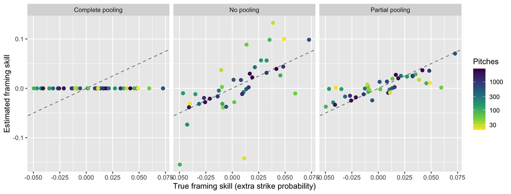

```r
sim_long <- sim |>
  pivot_longer(c(complete_pooling, no_pooling, partial_pooling),
               names_to = "approach", values_to = "estimate") |>
  mutate(approach = factor(
    approach,
    levels = c("complete_pooling", "no_pooling", "partial_pooling"),
    labels = c("Complete pooling", "No pooling", "Partial pooling")
  ))

ggplot(sim_long, aes(x = true_skill, y = estimate, color = pitches)) +
  geom_abline(linetype = "dashed", color = "gray50") +
  geom_point(size = 2) +
  facet_wrap(~ approach) +
  scale_color_viridis_c(trans = "log10", direction = -1) +
  labs(x = "True framing skill (extra strike probability)",
       y = "Estimated framing skill", color = "Pitches")
```

- **Complete pooling** ignores every real difference.
- **No pooling** scatters the small samples (yellow) far from the line.
- **Partial pooling** pulls the small samples toward 0 and leaves the large samples on the line.

```r
sim_long |>
  group_by(approach) |>
  summarize(rmse = sqrt(mean((estimate - true_skill)^2)))
```

```
# A tibble: 3 × 2
  approach           rmse
  <fct>             <dbl>
1 Complete pooling 0.0315
2 No pooling       0.0429
3 Partial pooling  0.0195
```

- Partial pooling has the smallest error (0.020).
- No pooling (0.043) is *worse* than assuming every catcher is average (0.032).

Each arrow runs from the no-pooling estimate to the partial-pooling estimate.

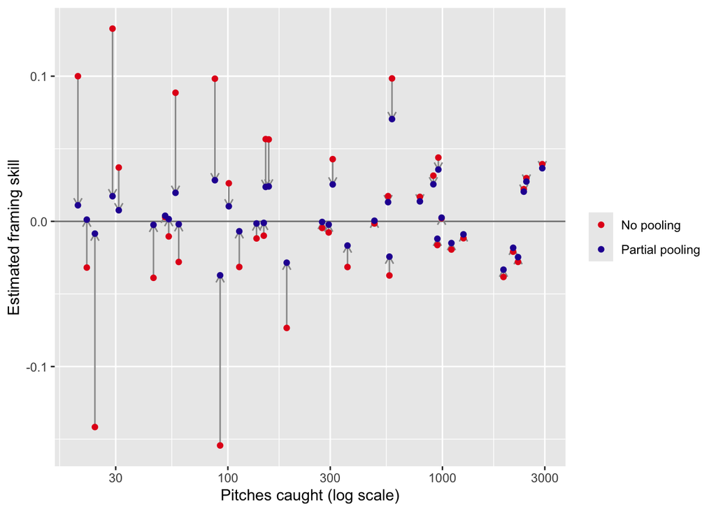

```r
shrinkage_plot <- function(data, y_label) {
  ggplot(data, aes(x = pitches)) +
    geom_hline(yintercept = 0, color = "gray50") +
    geom_segment(aes(xend = pitches, y = no_pooling, yend = partial_pooling),
                 arrow = arrow(length = unit(0.08, "inches")), color = "gray60") +
    geom_point(aes(y = no_pooling, color = "No pooling")) +
    geom_point(aes(y = partial_pooling, color = "Partial pooling")) +
    scale_color_manual(values = c("No pooling" = crc_fc[2],
                                  "Partial pooling" = crc_fc[1])) +
    scale_x_log10() +
    labs(x = "Pitches caught (log scale)", y = y_label, color = NULL)
}

shrinkage_plot(sim, "Estimated framing skill")
```

- Small samples (left) move the most. Large samples (right) barely move.
- This is the “I don’t believe you yet” behavior of partial pooling.

## When Should We Use a Mixed-Effects Model?

Every grouping in a model is either a fixed effect or a random effect.

| Use a **random** effect when… | Use a **fixed** effect when… |
| --- | --- |
| there are many groups (120 catchers). | there are only a few groups (home and away). |
| we view the groups as a sample from a larger population (this year’s catchers). | the groups are the complete set of possibilities (the 12 ball-strike counts). |
| some groups are small (a catcher with 8 pitches). | every group has plenty of data (thousands of pitches per count). |
| we care about the population of groups and want to shrink small samples. | we want to compare those exact groups directly (left-handed versus right-handed batters). |

- Mixed-effects models are especially useful when several groupings cross one another. Every pitch has a catcher, a pitcher, *and* a batter.
- A single model can contain both. Model A uses a fixed effect for `prob_strike` and a random effect for the catcher.

**Class activity.** Each pair below contains one fixed effect and one random effect. Which is which, and why?

1. In a model of called strikes: (a) the ball-strike count, or (b) the home plate umpire.
2. In a model of called strikes: (a) pitch type (four-seam, slider, changeup, and so on), or (b) the individual pitcher.
3. In a model of maintenance failures: (a) aircraft type (C-17, KC-135, F-16), or (b) the individual aircraft (tail number).
4. In a model of cadet GPA: (a) class year (four classes), or (b) cadet squadron.

**NoteDiscussion**

1. **Count is fixed.** There are only 12 counts, they are every count that exists, and each has thousands of pitches. **Umpire is random.** There are roughly 90 umpires, and some work far fewer games than others.
2. **Pitch type is fixed.** There are a handful of types, each has thousands of pitches, and we want to compare specific types. **Pitcher is random.** There are 870 pitchers, and many threw only a few innings.
3. **Aircraft type is fixed.** There are a few types, and we care about each one. **Tail number is random.** There are many aircraft, and some have flown far fewer hours than others.
4. **Class year is fixed.** There are exactly four classes, each with about 1,000 cadets. **Squadron is random.** There are 40 squadrons, and we view them as a sample of the squadrons that could exist.

## Reading the Model Syntax

`glmer()` uses the same formula syntax as `glm()`, plus one new term.

| Term | Meaning |
| --- | --- |
| `Outcome == "called_strike"` | The response: was the taken pitch called a strike? |
| `prob_strike` | A fixed effect: the GAM probability of a strike from the pitch location. |
| `(1 \| fielder_2_1)` | A random effect: each catcher has an intercept, drawn from a normal distribution with mean 0 and standard deviation $s_c$. |
| `family = binomial` | The response is a strike or a ball. We explain this with Model A below. |

Three functions read the fitted model:

- `fixef()`: the fixed effects.
- `VarCorr()`: $s_c$, how much catchers truly differ.
- `ranef()`: the partial-pooling estimate for each catcher.

# Part C: Modeling Catcher Framing (Section 7.5)

In this section, we fit the two models from Section 7.5 to every taken pitch of 2022, rather than to the textbook’s sample of 50,000 pitches.

## Model A: Catcher Effects Only

$$\log\frac{p_j}{1-p_j} = \beta_0 + \beta_1 \cdot \texttt{prob\_strike}_j + \alpha_{c(j)},$$

- $p_j$ is the probability that pitch $j$ is called a strike.
- The right side adds three pieces: a baseline $\beta_0$, the location effect $\beta_1 \cdot \texttt{prob\_strike}_j$, and the effect $\alpha_{c(j)}$ of the catcher who received pitch $j$.

Notice that the code below uses `Outcome == "called_strike"` as the response, but the equation has $\log\frac{p_j}{1-p_j}$ on the left. The two match as follows:

| Code | Equation |
| --- | --- |
| `Outcome == "called_strike"` | The outcome we observe: a strike (`TRUE`) or a ball (`FALSE`). We model its probability, $p_j$. |
| `family = binomial` | The outcome is a strike or a ball, so the right side predicts the log-odds, $\log\frac{p_j}{1-p_j}$. |
| `prob_strike` | $\beta_0 + \beta_1 \cdot \texttt{prob\_strike}_j$ |
| `(1 \| fielder_2_1)` | $\alpha_{c(j)}$ |

- Why the log-odds? The right side can be any number, but a probability must stay between 0 and 1. The log-odds can also be any number, so every value on the right side corresponds to a valid probability.
- We used the same setup for the GAM, which also had `family = binomial`. The function `plogis()` converts the log-odds back to a probability.

```r
mod_a <- glmer(
  Outcome == "called_strike" ~ prob_strike + (1 | fielder_2_1),
  family = binomial,
  data = taken
)
fixef(mod_a)
```

```
(Intercept) prob_strike
  -4.003539    7.627854
```

```r
VarCorr(mod_a)
```

```
 Groups      Name        Std.Dev.
 fielder_2_1 (Intercept) 0.2117
```

- The catcher effects are on the log-odds scale.
- We convert them to strikes. For each pitch, we compute the log-odds with and without the catcher’s effect, convert both to probabilities with `plogis()`, and take the difference. Summing over the season gives strikes added.

```r
catcher_strikes <- function(mod) {
  eta <- predict(mod, type = "link")
  b <- ranef(mod)$fielder_2_1[as.character(taken$fielder_2_1), 1]
  taken |>
    mutate(strikes = plogis(eta) - plogis(eta - b)) |>
    group_by(fielder_2_1) |>
    summarize(strikes_added = sum(strikes))
}
```

## Complete, No, and Partial Pooling with Real Data

Please note that our naive `strikes_added` *is* the no-pooling estimate.

```r
pooling <- taken |>
  group_by(fielder_2_1) |>
  summarize(
    pitches = n(),
    no_pooling = sum(Outcome == "called_strike") - sum(prob_strike)
  ) |>
  left_join(
    catcher_strikes(mod_a) |> rename(partial_pooling = strikes_added),
    by = "fielder_2_1"
  ) |>
  mutate(complete_pooling = 0) |>
  left_join(player_names, by = c("fielder_2_1" = "mlb_id")) |>
  relocate(catcher = name)
pooling
```

```
# A tibble: 120 × 6
   catcher       fielder_2_1 pitches no_pooling partial_pooling complete_pooling
   <chr>               <dbl>   <int>      <dbl>           <dbl>            <dbl>
 1 Yadier Molina      425877    5420      48.1           58.5                  0
 2 Kurt Suzuki        435559    3071     -50.8          -41.4                  0
 3 Manny Piña         444489     415      -5.36          -1.80                 0
 4 Martín Maldo…      455117    7671     -12.1           -0.505                0
 5 Robinson Chi…      455139    4551    -122.          -102.                   0
 6 Jason Castro       488771    1614     -16.3          -11.0                  0
 7 Sandy León         506702    1911       9.32           8.44                 0
 8 Travis d'Arn…      518595    7410      51.5           57.3                  0
 9 Yasmani Gran…      518735    4687      35.8           37.5                  0
10 Austin Romine      519222    3102     -38.1          -27.3                  0
# ℹ 110 more rows
```

Strikes added per 100 taken pitches under each approach.

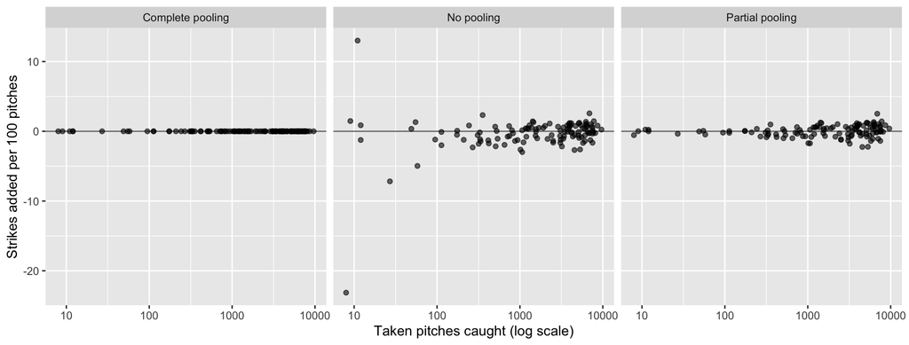

```r
pooling |>
  pivot_longer(c(complete_pooling, no_pooling, partial_pooling),
               names_to = "approach", values_to = "strikes_added") |>
  mutate(
    approach = factor(
      approach,
      levels = c("complete_pooling", "no_pooling", "partial_pooling"),
      labels = c("Complete pooling", "No pooling", "Partial pooling")
    ),
    rate = 100 * strikes_added / pitches
  ) |>
  ggplot(aes(x = pitches, y = rate)) +
  geom_hline(yintercept = 0, color = "gray50") +
  geom_point(alpha = 0.6) +
  facet_wrap(~ approach) +
  scale_x_log10() +
  labs(x = "Taken pitches caught (log scale)",
       y = "Strikes added per 100 pitches")
```

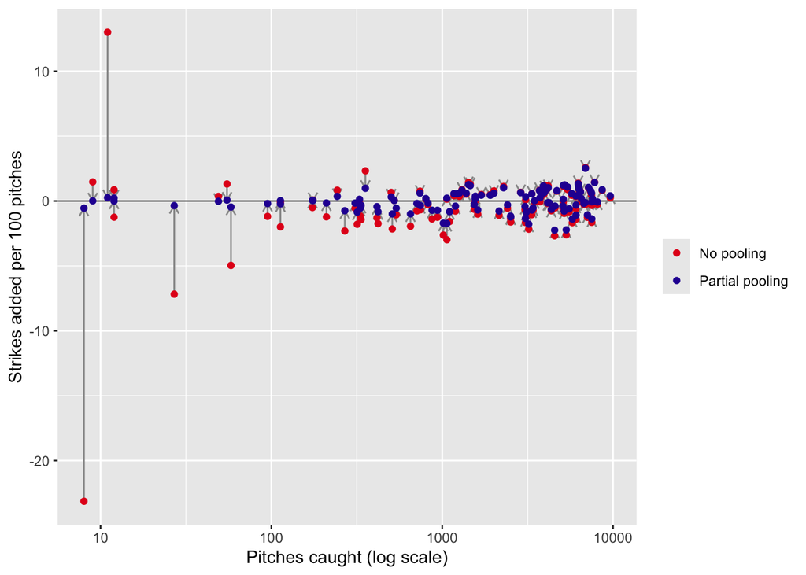

```r
pooling |>
  mutate(
    no_pooling = 100 * no_pooling / pitches,
    partial_pooling = 100 * partial_pooling / pitches
  ) |>
  shrinkage_plot("Strikes added per 100 pitches")
```

- The real data behave exactly like the simulation.

Six catchers up close.

```r
pooling |>
  filter(catcher %in% c("Yermín Mercedes", "Donny Sands", "Caleb Hamilton",
                        "Jose Trevino", "Brian Serven", "Christian Vázquez")) |>
  mutate(
    no_pooling_per_100 = 100 * no_pooling / pitches,
    partial_pooling_per_100 = 100 * partial_pooling / pitches
  ) |>
  select(catcher, pitches, no_pooling, partial_pooling,
         no_pooling_per_100, partial_pooling_per_100) |>
  arrange(pitches)
```

```
# A tibble: 6 × 6
  catcher           pitches no_pooling partial_pooling no_pooling_per_100
  <chr>               <int>      <dbl>           <dbl>              <dbl>
1 Donny Sands             8      -1.85         -0.0440            -23.1
2 Yermín Mercedes        11       1.43          0.0276             13.0
3 Caleb Hamilton        355       8.25          3.48                2.32
4 Brian Serven         4170      48.5          42.7                 1.16
5 Jose Trevino         6893     177.          174.                  2.57
6 Christian Vázquez    7484      32.5          45.4                 0.434
# ℹ 1 more variable: partial_pooling_per_100 <dbl>
```

- **Mercedes (11 pitches) and Sands (8 pitches):** the highest and lowest rates in baseball with no pooling, and nearly 0 with partial pooling. The textbook’s 50,000-pitch sample ranks Sands as the *best* framer.
- **Hamilton (355 pitches):** falls from 2.3 to 1.0 strikes per 100 pitches.
- **Trevino (6,893 pitches):** nearly identical under both approaches.
- **Serven versus Vázquez:** similar totals (42.7 versus 45.4), but Serven adds more per 100 pitches (1.02 versus 0.61). Serven is the better framer per pitch.

## Model B: Adding Pitcher and Batter Effects

$$\log\frac{p_j}{1-p_j} = \beta_0 + \beta_1 \cdot \texttt{prob\_strike}_j + \alpha_{c(j)} + \gamma_{p(j)} + \delta_{b(j)},$$

where $\gamma_{p(j)}$ is the effect of the pitcher and $\delta_{b(j)}$ is the effect of the batter. This model takes about 1 to 2 minutes to fit.

```r
mod_b <- glmer(
  Outcome == "called_strike" ~ prob_strike +
    (1 | fielder_2_1) + (1 | batter) + (1 | pitcher),
  family = binomial,
  data = taken
)
VarCorr(mod_b)
```

```
 Groups      Name        Std.Dev.
 pitcher     (Intercept) 0.22764
 batter      (Intercept) 0.19242
 fielder_2_1 (Intercept) 0.20481
```

- Standard deviations: pitcher 0.23, catcher 0.20, batter 0.19.
- The pitcher is the largest source of variation. The catcher is about as important as the batter.

Naive, Model A, and Model B strikes added for the top 15 catchers, with Model B converted to runs.

```r
framing_compare <- pooling |>
  select(catcher, fielder_2_1, pitches, naive = no_pooling, model_a = partial_pooling) |>
  left_join(
    catcher_strikes(mod_b) |> rename(model_b = strikes_added),
    by = "fielder_2_1"
  ) |>
  mutate(runs_b = model_b * strike_value) |>
  arrange(desc(model_b))
framing_compare |> slice_head(n = 15)
```

```
# A tibble: 15 × 7
   catcher           fielder_2_1 pitches naive model_a model_b runs_b
   <chr>                   <dbl>   <int> <dbl>   <dbl>   <dbl>  <dbl>
 1 Jose Trevino           624431    6893 177.    174.    145.   19.9
 2 Sean Murphy            669221    8639  70.3    75.1    87.4  12.0
 3 Jonah Heim             641680    7795 113.    111.     76.6  10.5
 4 Travis d'Arnaud        518595    7410  51.5    57.3    76.4  10.5
 5 Adley Rutschman        668939    6251  85.6    82.9    76.2  10.5
 6 Omar Narváez           553882    6294  69.1    72.5    75.5  10.4
 7 Alejandro Kirk         672386    5205  63.8    64.7    67.9   9.32
 8 Cal Raleigh            663728    7187  72.6    74.9    66.3   9.09
 9 Tomás Nido             621512    6310  59.6    60.1    56.4   7.74
10 Yadier Molina          425877    5420  48.1    58.5    56.4   7.73
11 Brian Serven           661531    4170  48.5    42.7    54.5   7.47
12 Víctor Caratini        605170    6357  42.4    54.3    49.3   6.76
13 Tyler Heineman         623168    3913  41.4    45.5    46.2   6.34
14 Kyle Higashioka        543309    5124  58.1    62.0    46.1   6.32
15 Christian Vázquez      543877    7484  32.5    45.4    45.7   6.27
```

- **Trevino** is first in every model, but falls from 174 strikes (Model A) to 145 (Model B).
- **Heim** falls from 111 to 77 strikes, while **d’Arnaud** rises from 57 to 76. Part of Heim’s credit appears to belong to Heim’s pitchers.
- Trevino’s 145 strikes are worth about 20 runs, roughly three-quarters of the batting value of the 20th-best hitter in 2022 (26 runs).

## Revisiting the Two Problems

1. **Several players influence every call.** Solved in part. Model B estimates the catcher, pitcher, and batter effects at the same time.
2. **Unequal sample sizes.** Solved. Partial pooling shrinks small samples toward the league average.

What the model still leaves out:

- **Umpires.** The `umpire` column is empty. With umpire data from another source, we would add `(1 | umpire)`.
- **Count.** Recall from Chapter 6 that the zone changes with the count. We could add `Count` as a fixed effect.
- **Batter height.** The GAM uses one zone for every batter.

Thus, the mixed-effects model is not a complete analysis of framing, but it addresses both problems from Part A, and the same approach applies to any problem in which we must separate the contributions of several players.